# Projekt 2 Faza 1 - Analiza postów z Alior Banku

Ewa Baranowska, Dorota Łępicka, Michał Stolarczyk, Michał Mück

13 maja 2016

### Przygotowanie danych

Nasze dane dotyczyły postów ze strony fanpage’a AliorBanku na facebooku. Przed przystąpieniem do analiz przepuściliśmy teksty postów przez korektę językową, po czym wybraliśmy z nich słowa zakwalifikowane jako rzeczowniki i wzięliśmy ich formę podstawową. Otrzymany wynik nie do końca nas satysfakcjonował dlatego usunęliśmy z otrzymanych rzeczowników tzw. stopwordsy, a rzeczowniki odczasownikowe, których formą podstawową jest czasownik i jako czasownik były zwracane przez aplikację, zamieniliśmy z powrotem na rzeczowniki. Wyłuskane w ten sposób rzeczowniki zapisawaliśmy w formie wyraz1|wyraz2|… do nowej kolumny. W wyniku tych działań otrzymaliśmy zbiór danych danych postaci:

| id | parent_id | created_at | thread_id | subject | user_name | user_link | source | body | rzeczowniki |
| --- | --- | --- | --- | --- | --- | --- | --- | --- | --- |
| 1255 | 1252 | 2013-10-02 07:54:15 | 178 | NA | Alior Bank SA |  | https://www.facebook.com/AliorBankSA | Ewa Kinga: :) [Magda] | ewa\|kinga\|magda |

# Z punktu widzenia: rzeczowników

### Statystyki dla rzeczowników

Spójrzmy na podstawowe statystyki dotyczące rzeczowników w badanych tekstach. W naszych danych udało nam się wyodrębnić łącznie **114 497** rzeczowników, w tym **10 825** różnych (co stanowi **9.5%** całej liczby). Patrząc na rozkład ilości wystąpień rzeczowników, widzimy bardzo mocną prawostronną skośność (górny kwantyl poniżej 5, przy maksimum równym **2609**). Wynika ona z faktu, że w zbiorze znajduje się wiele rzeczowników, które pojawiły się tylko raz w postach.

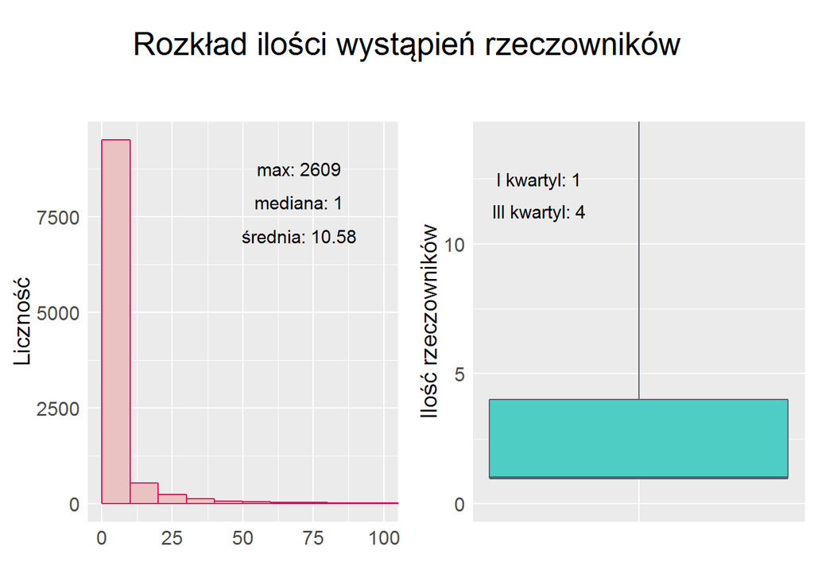

Spójrzmy na tabelę rozkładu ilości wystąpień. Widać z niej, że ponad połowa rzeczowników wystąpiła zaledwie raz.

| 1 raz | 2-5 | 6-10 | 11-50 | 51-100 | 101-1000 | 1001-2609 |
| --- | --- | --- | --- | --- | --- | --- |
| 5591 | 3181 | 736 | 969 | 168 | 171 | 9 |
| 51.65% | 29.39% | 6.8% | 8.95% | 1.55% | 1.58% | 0.08% |

Jako, że najprawdopodobniej większość z tych pojedynczych rzeczowników nie będzie miała większego znaczenia w analizach (literówki, przypadkowe użycie etc.), przedstawmy rozkład ilości wystąpień rzeczowników, ale bez tych pojedynczych wystąpień. Widać teraz, że górny kwantyl wzrósł o ponad połowę i wynosi teraz 11,a mediana 4. Zatem jeśli dane słowo się powtarzało przynajmniej raz, to połowa takich słów miała liczbę wystąpień większą lub równą 4.

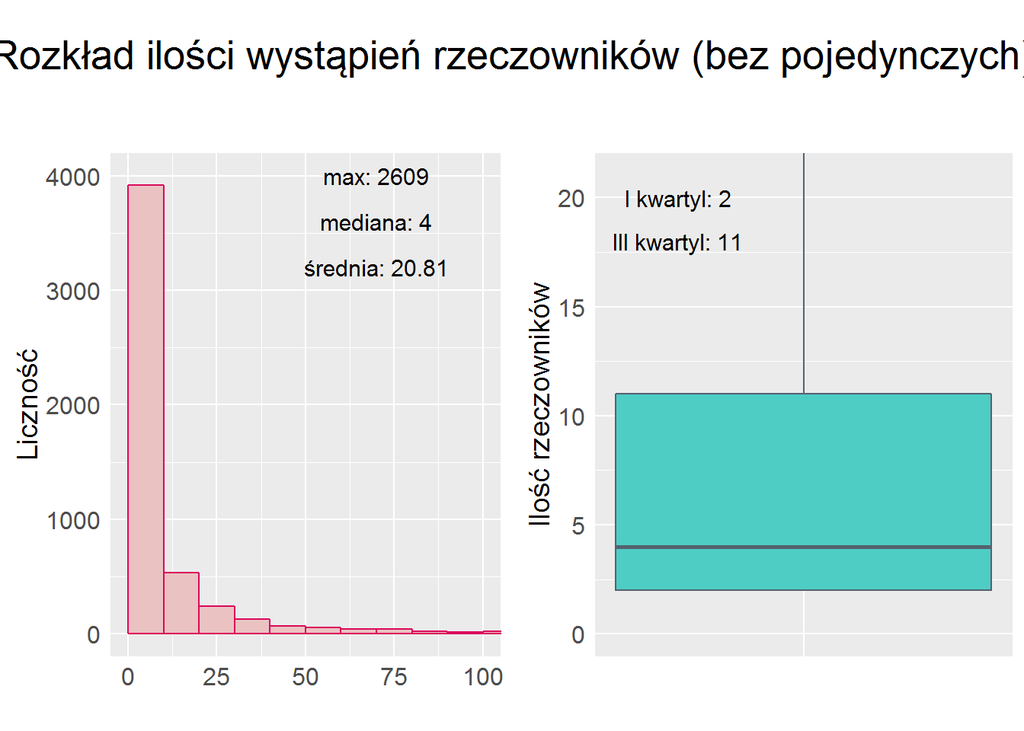

### Najpopularniejsze słowa

Zobaczmy graficznie jak przedstawiają się najpopularniejsze słowa. Widać, że większość słów jest związana z branżą bankową, tj. klient, konto, rachunek czy przelew. Warto zwrócić uwagę, że wśród tych najczęstszych słów znajdują się dwa imiona - Magda i Kuba. Wynika to z faktu, że na posty użytkowników w imieniu banku odpowiadały osoby o tych imionach, które zawsze pod koniec posta umieszczały swoje imię.

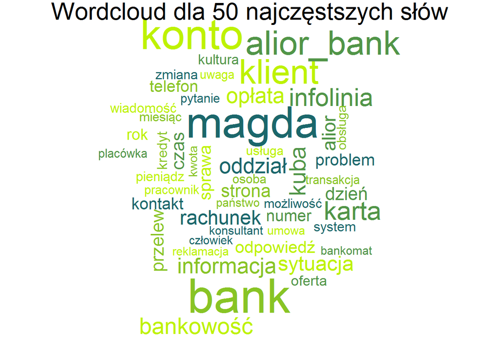

Przedstawmy ranking 10 najpopularniejszych słów wraz z ich statystykami. Jak widać najczęstszym słowem jest oczywiście **bank** z liczbą wystąpień równą **2609**. To słowo występowało w **17%** postów. Kolejnym słowem jest wspomniana Magda (**15%** postów), konto, klient, itd.

| word | rank | rank per post | count | procent | procent per post |
| --- | --- | --- | --- | --- | --- |
| bank | 1 | 1 | 2609 | 2.28 | 16.73 |
| magda | 2 | 2 | 2356 | 2.06 | 15.11 |
| konto | 3 | 3 | 2248 | 1.96 | 14.42 |
| klient | 4 | 4 | 1778 | 1.55 | 11.40 |
| alior_bank | 5 | 5 | 1715 | 1.50 | 11.00 |
| karta | 6 | 6 | 1248 | 1.09 | 8.00 |
| infolinia | 7 | 7 | 1182 | 1.03 | 7.58 |
| kuba | 8 | 8 | 1049 | 0.92 | 6.73 |
| bankowość | 9 | 9 | 1042 | 0.91 | 6.68 |
| informacja | 10 | 10 | 988 | 0.86 | 6.34 |

W tabeli umieściliśmy 2 liczby procentowe i 2 rankingi. Pierwszy ranking i procenty odnoszą się do łącznej liczby wystąpień, natomiast drugie do łącznej liczby dokumentów. Jak widać rankingi te pokrywają się dla tych 10 najpopularniejszych słów. W większości przypadków rangi poszczególnych słów pokrywają się lub różnią o zaledwie parę pozycji. Słowa, dla których te rankingi różnią się o więcej niz 5 wylistowaliśmy poniżej. Jest ich 14 i są to tylko rzeczowniki odczasownikowe. Występowały one częściej per post niż w łącznej sumie rzeczowników. Zwróćmy uwagę, że dla każdego z tych słów ranga w rankingu wg występowania jest wyższa (jest wyżej w rankingu) niż ranga z rankingu per post. Zatem jeśli te słowo wystąpiło to raczej w jednym poście kilkukrotnie niż pojedynczo w wielu postach.

| word | rank | rank per post | count | procent | procent per post | rozn |
| --- | --- | --- | --- | --- | --- | --- |
| zameldowanie | 3609 | 5175 | 3 | 0.00 | 0.01 | 1566 |
| wydawanie | 2037 | 2340 | 6 | 0.01 | 0.03 | 303 |
| anulowanie | 972 | 1095 | 15 | 0.01 | 0.08 | 123 |
| zamieszkanie | 1413 | 1532 | 10 | 0.01 | 0.06 | 119 |
| powstanie | 1391 | 1485 | 10 | 0.01 | 0.06 | 94 |
| doładowanie | 566 | 631 | 29 | 0.03 | 0.17 | 65 |
| wygranie | 813 | 873 | 20 | 0.02 | 0.12 | 60 |
| postępowanie | 431 | 470 | 39 | 0.03 | 0.23 | 39 |
| przetwarzanie | 694 | 715 | 24 | 0.02 | 0.15 | 21 |
| przewalutowanie | 365 | 381 | 49 | 0.04 | 0.30 | 16 |
| księgowanie | 468 | 480 | 36 | 0.03 | 0.22 | 12 |
| posiadanie | 472 | 482 | 36 | 0.03 | 0.22 | 10 |
| logowanie | 113 | 121 | 154 | 0.13 | 0.92 | 8 |
| spotkanie | 407 | 414 | 42 | 0.04 | 0.26 | 7 |

Zobaczmy przykładowy post dla słowa “anulowanie”:

**————————————————————–**

“Skontaktowałam się z Waszą infolinią, i co? I nic. Nadal wniosek wisi w powietrzu, nie ma go komu anulować, mija już 5 dzień a ja chciałam założyć w Waszym banku konto firmowe, chyba popełniłabym największy błąd w życiu bo jak miałaby działać tak samo obsługa mojego konta jak **anulowanie** wniosku, to ja bardzo podziękuje. Dzięki temu, że wniosek nadal jest aktywny wstrzymaliście mi możliwość zaciągnięcie np. pożyczki w innym banku. Jest to nie dopuszczalne, od 5 dni czekam na **anulowanie** wniosku, Wasz "bank" jest po prostu zły! Jak można tyle czekać na **anulowanie**? **Anulowanie** własnego wniosku, Wam jak raty nie zapłacę w terminie to mało głowy człowiekowi nie urwiecie! Straszycie, szantażujecie etc. Dość tego, mam prawo napisać na Was skargę. I zrobię to.”

**————————————————————-**

Czyli rzeczywiście dane potwierdzają powyższy wniosek. W przytoczonym przykładzie klient chce anulować wniosek i aby opisać swoją prośbę/problem wprost kilkukrotnie używa słowa “anulowanie”.

### Statystyki dla postów

Przyjrzyjmy się teraz rozkładowi rzeczowników w postach. W zbiorze danych mamy **15 594** posty, a na post przypada średnio **7.34** rzeczownika. Ten rozkład jak można było się spodziewać jest również prawostronnie skośny, mamy dużo postów z małą ilością rzeczowników

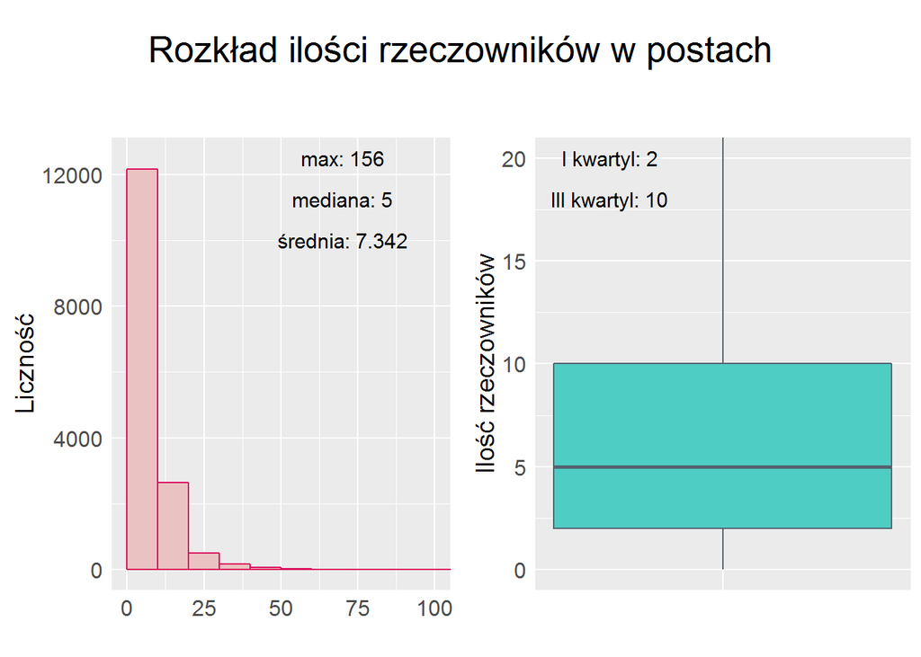

Maksymalna ilość rzeczowników w jednym poście wynosiła **156**. Post o największej ilości rzeczowników dotyczył opisu sytuacji, która miała miejsce w banku, więc duża ilość rzeczowników wynikała po pierwsze z charakteru postu jako opisu, a po drugie z jego znacznej długości.

### Rozkład wybranych słów w czasie

Spójrzmy na rozkład wybranych popularnych słów w czasie. Nasze dane pochodzą z okresu od **20 czerwca 2013** roku do **28 lutego 2016** roku, czyli mamy dane z **984** dni. W celu wykrycia nietypowych sytuacji przeanalizowaliśmy wykresy ilości wystąpień charakterystycznych słów w czasie liczonym w tygodniach. Jako nietypową liczbę wystąpień danego słowa potraktowaliśmy liczbę większą od 3 odchyleń standardowych dla wystąpień danego słowa. Z tych nietypowych liczb wybieraliśmy tą maksymalną i dla niej przeglądaliśmy posty z danego tygodnia w celu sprawdzenia powodu tak nagłego wzrostu wystapień wybranego słowa.

Zanalizowaliśmy wykres dla słowa “problem” i “awaria”. Z wykresu dla “problemu” widać wyraźny pik w okolicach początku 2014.

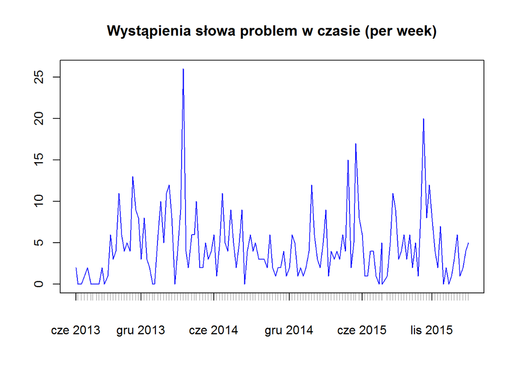

Przyjrzyjmy się typowemu postowi z tygodnia, który odpowiadał temu pikowi. Jak widać problem dotyczył logowania się online na stronie internetowej banku.

| created_at | body |
| --- | --- |
| 2014-03-12 07:39:17 | czy ktoś ma dzisiaj taki sam problem ?? jak długo może to potrwać ?? Nie można połączyć się z prawdziwą witryną aliorbank.pl Coś zakłóca bezpieczne połączenie z aliorbank.pl. Spróbuj ponownie załadowa… |

Podobnie zrobiliśmy dla słowa “awaria”. Wyraźny skok był widoczny koło czerwca 2015. Z typowego postu dla tego tygodnia wynika, że awaria dotyczyła bankomatów.

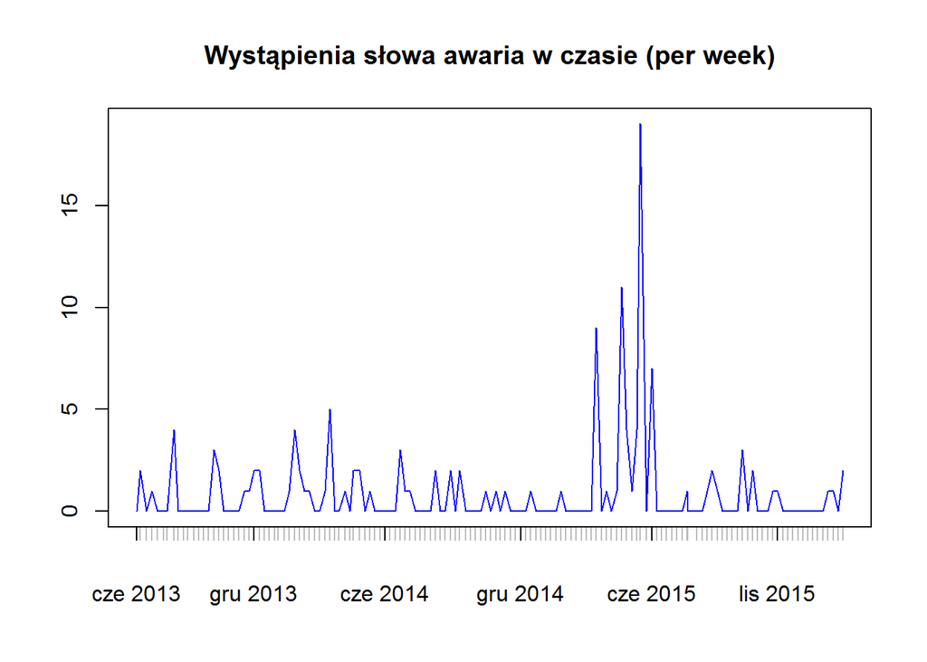

| created_at | body |
| --- | --- |
| 2015-05-21 16:18:02 | Czy jest jakas awaria? Nie moge wyplacic w bankomacie zadnej sieci, blad 413 - warszawa wlochy |

# Z punktu widzenia: grup nadawców

W tym punkcie dokonując analizy rzeczowników w komentarzach Alior Banku zostały dodatkowo usunięte imiona i nazwiska (bądź wymyślone nazwy) adresatów postów. Aktywny udział (więcej niż 1 komentarz) brało **4645** różnych użytkowników. Przedstawimy teraz kilka podstawowych statystyk dotyczących pracowników banku oraz 3 najaktywniejszych osób: Łukasza Majewskiego, Tomasza Ziółkowskiego i Pawła Krawca.

| Użytkownik | Liczba postów | Różnych rzeczowników | Suma rzeczowników | Największa aktywność |
| --- | --- | --- | --- | --- |
| Alior Bank SA | 5032 | 3788 | 37397 | 2014-05-05 |
| Łukasz Majewski | 278 | 612 | 2170 | 2013-10-22 |
| Tomasz Ziółkowski | 111 | 287 | 546 | 2014-04-02 |
| Paweł Krawiec | 89 | 241 | 390 | 2014-07-08 |

Na poniższym wykresie przedstawiliśmy rozkład sumy rzeczowników z podziałem na lata u trzech najaktywniejszych użytkowników.

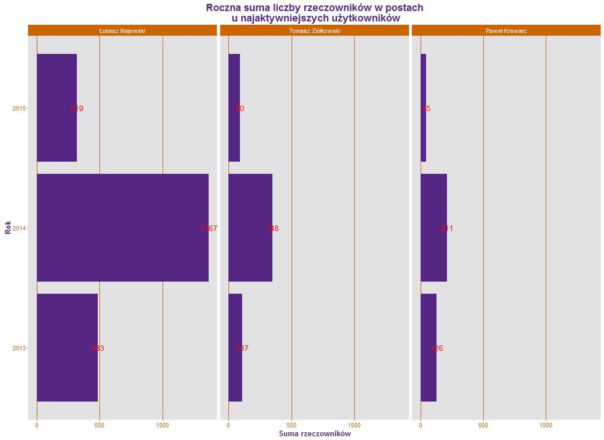

Możemy zaobserwować, że u wszystkich użytkowników najwięcej rzeczowników było w komentarzy w 2014 roku. Widać również skrajne różnice w sumie rzeczowników między nadawcami, ale procentowy udział w 2014 Majewski - 63%, Ziółkowski - 64%, Krawiec - 54% jest podobny. Wszyscy panowie nie pisali już komentarzy w 2016 roku.

Przyjrzyjmy się teraz jakie rzeczowniki powtarzały się najczęściej w komentarzach użytkowników i Alior Banku.

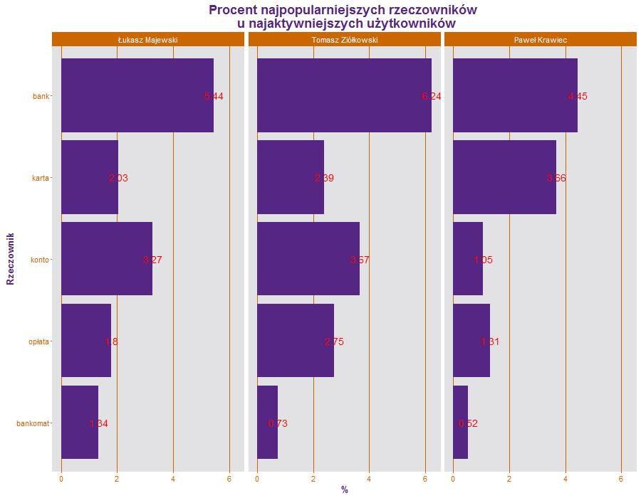

Jak widać panowie Łukasz i Tomasz używali podobnych rzeczowników, natomiast Paweł nieco odbiega od nich. W postach p.Krawca na czołowych miejscach znajdowały się również słowa: oddział, klient i farsa, których nie było w pierwszej 10 u pozostałych osób.

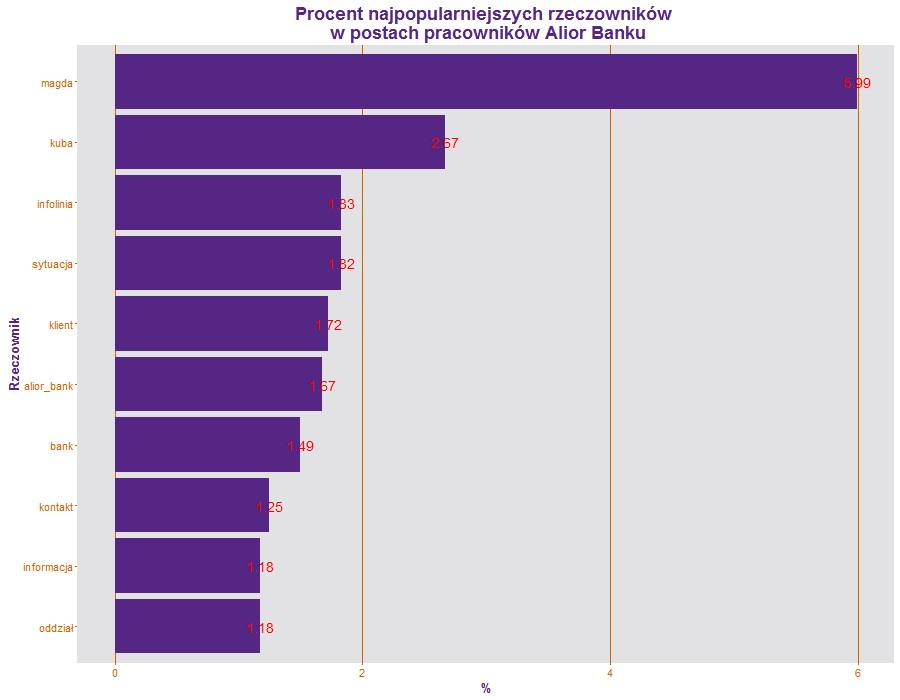

Możemy również zauważyć, że 7/10 najpopularniejszych rzeczowników w postach Alior Banku pokrywają się z ogólnymi statystykami.

# Z punktu widzenia: wątków

W zbiorze danych znajdują się **15594** posty zgrupowane w **3276** wątkach. Średnia liczba postów w wątku wynosi **4.76**, natomiast mediana jest równa **3**.

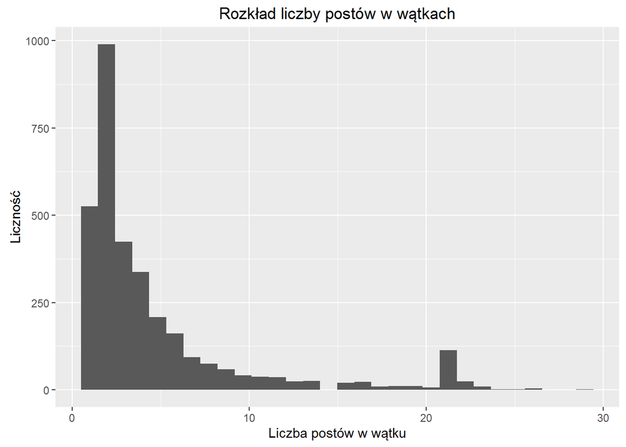

Posty w jednym wątku powinny mieć zbliżony temat, dlatego w dalszej analizie wątki będziemy traktować jak jeden tekst. Aby znaleźć problemy jakie napotykają klienci, szukaliśmy słów kluczowych: **awaria, problem, uwaga**. Wątki z dużą liczbą takich słów będą prawdopodobnie zawierały uwagi dotyczące usług banku. Poniższy wykres przedstawia zależność liczby takich słów w wątkach od czasu.

Dodatkowo po najechaniu na punkt, jest wyświetlane id wątku oraz 5 najbardziej *charakterystycznych* słów. *Charakterystyczność* słowa dla wątku mierzyliśmy za pomocą wag **tfidf**. Waga **tfidf** dla słowa $i$ w tekście $j$ jest zdefiniowana jako
$$\mathrm{tfidf}_{ij} = \mathrm{tf}_{ij} \cdot \mathrm{idf}_{i},$$
gdzie $\mathrm{tf}_{ij}$ jest częstością występowania słowa $i$ w tekście $j$, natomiast $\mathrm{idf}_{i}$ jest logarytmem ilorazu liczby tekstów przez liczbę dokumentów, w których występuje $i$-te słowo.

Gdy słowo występuje w większości tekstów, idf będzie małe, dzięki czemu waga dla tego słowa też będzie mała. Natomiast gdy słowo występuje w niewielu tekstach, to idf będzie duże, przez co waga $\mathrm{tfidf}$ również będzie rosła.

Poniżej przedstawiamy dwa wątki z największą liczbą słów kluczowych.

#### id = 221343

- Witam. Mam pewne uwagi, co do waszego serwisu i pomocy technicznej. Mam problem z smsami zawierającymi hasła jednorazowe. Polega on na tym, że te smsy nie dochodzą do mnie. Dzwoniłem do was, konsultanci sprawdzali, niby wszystko jest ok, smsy zostały wysłane, potwierdzenia otrzymane. Dzwoniłem do mojego operatora nju mobile, zostały wyłączone usługi blokowania, ale problem nadal występował. Zgłosiłem to jeszcze raz do operatora, konsultant zgłosił to do działu technicznego. Cała sprawa miała miejsce wczoraj, dzisiaj dostałem odpowiedź od działu technicznego, że żadne smsy z banku nie dotarły do nich i że problem leży po waszej stronie. Kolejny telefon do konsultanta i znowu słyszę, że problem jest po stronie operatora. Powiedziałem, że skoro tak, to żeby bank skontaktował się z moim operatorem i rozwiązał sprawę. Wtedy usłyszałem, że to jest nie możliwe ponieważ ja jestem klientem waszego banku i mojego operatora komórkowego i skoro problem nie leży po Waszej stronie, to żebym się kontaktował z operatorem. Zmarnowałem ponad godzinę czasu na rozmowy telefoniczne i problem nadal występuje. Waszym hasłem reklamowym jest: Wyższa kultura bankowości - jestem ciekaw na czym ona polega skoro w taki sposób traktujecie nowych klientów Waszego banku.
- @Marcin: Bardzo prosimy, abyś zgłosił ten problem za pośrednictwem panelu “Wiadomości” w bankowości internetowej. Zweryfikujemy je i udzielimy Ci indywidualnej odpowiedzi. [Magda]
- Zgłosił problem drogą internetową ? Dzwoniłem kilku krotnie na waszą infolinię, proszę zapytać konsultantów o moją sprawę. Ja nie mam czasu na zgłaszanie po 10 razy tego samego telefonicznie, czy w jaki kolwiek inny sposób. Proszę się skontaktować z Nju Mobile i wspólnie rozwiązać mój problem.
- Stary zmień Bank, ja też kiedyś u nich miałem konto, lecz ten związek nie przetrwał próby czasu:) Generalnie nie polecam.
- Problem rozwiązany. Problem leży po stronie systemu operacyjnego. Teraz doczytałem się w internecie o tym. Przepraszam za zbędne zamieszanie, ale zdezorientowały mnie sprzeczne informacje z banku i operatora.
- Nie wysylaja smsow,bo brakuje im kompetencji w obsludze klienta:)

#### id = 1200716

- Mamy już za sobą ostatnią odsłonę połączenia Meritum Banku z Alior Bankiem. Serdecznie witamy na naszym profilu dotychczasowych fanów Meritum Banku. W tym miejscu będziemy dzielić się z Wami najważniejszymi informacjami dotyczącymi Alior Banku. Tu także będziecie mogli brać udział w konkursach i wygrać atrakcyjne nagrody m.in. bilety na mecze piłkarskiej Reprezentacji Polski oraz bilety do kina. Zapraszamy Was także do dzielenia się opiniami lub komentarzami. Jesteśmy do Waszej dyspozycji :)
- Jsk zmienić konto z gwarancją na konto internetowe
- Weście sie za robote i zrobię raz na zawsze pozadnie ta stronę z bankowością intrenetowa od rana probuje zrobic przelewe a tu sie niewyswietna numer konta tylko napisz wybierz a co mam kurde wybrac jaja Se robicie to pilna sprawa ! A wasze przepraszam za utrudnianie mi niepomaga
- Najlepiej zmienić bank !!! W innych niema problemów z tak blachymi sprawami
- Ja jakos jestem klientka Alior Banku od 2009 roku i nigdy zadnych problemow nie mam…
- Ją jestem klientem od 2 i też nigdy nie mialem
- kijowy bank
- System internetowej bankowości Alior Banku to bardzo intuicyjna aplikacja, poważnie. Z czym konkretnie ma Pani problem odnośnie przelewu?
- Jestem klientka od 6lat nigdy nie mam problemu.Obsługa super miła i zawsze uśmiech na twarzy
- Beznadzieja. Przez to, ze wykupili Meritum mam teraz same problemy i zero pomocy z ich strony. Odradzam!
- Pati Krysiuk, prosimy o informację, w czym możemy Ci pomóc [Justyna]
- Marzena Wałaszek, w przypadku problemów z bankowością internetową prosimy o kontakt z nasza infolinią pod numerem 19 502, nasi konsultanci zweryfikują sprawę i pomogą rozwiązać problem. [Justyna]
- Marzena Wałaszek, w przypadku problemów z bankowością internetową prosimy o kontakt z nasza infolinią pod numerem 19 502, nasi konsultanci zweryfikują sprawę i pomogą rozwiązać problem. [Justyna]
- Kasia Sławińska-Kula, z chęcią odniesiemy się do Twoich konkretnych uwag. [Justyna]
- Mariola Kubacka dziękujemy za opinie!
- Ania Kowalczyk cieszymy się, że spełniamy twoje oczekiwania. [Kuba]
- Piotr Dowgiert dziękujemy za Twoją opinię! :)
- Napisalam w poscie na strone, gdzie ktos obiecal pomoc i dalej nic.
- Ja niestety jestem klientem “przejętym” razem z Meritum. Niestety - zupełnie nie z mojej winy zostałem pozbawiony na ponad tydzień dostępu do bankowości elektronicznej spółki. Przez tydzień zderzałem się z niekompetencją i niedoinformowaniem pracowników infolinii oraz w oddziale. Po wpisie na FB opieka się zmieniła - skontaktował się ze mną kompetentny pracownik infolinii, ale niestety nie pomógł - okazało się, że przywrócenie dostępu wymaga przeprowadzanie procedury analogicznej do zakładania rachunku firmowego, z wizytą w oddziele i w obecności pełnej reprezentacji spółki. Wskazano oddział, gdzie kompetentny pracownik, nie bez drobnych problemów systemowych, nas obsłużył. Niestety - strata wielu godzin cennego czasu (dwie dwugodzinne wizyty w oddziale, dojazd, długie rozmowy z infolinią - w sumie dzień pracy zebrałby się spokojnie) przy tak drobnej sprawie jest chyba przez bank nie do zrekompensowania. Wprawdzie w tym tygodniu usłyszałem kilka razy “przepraszamy”, ale to mało i nie widzę możliwości poprawy złego wrażenia. Pozdrawiam wszystkich zadowolonych.
- Klaudia zmiana Konta z Gwarancją na Konto Internetowe jest możliwa z pomocą konsultanta poprzez nasza infolinię pod numerem 19 502. [Kuba]
- również jestem klientem “przejętym” z meritumbanku i niestety analogicznie jak poprzednik zostałem pozbawiony dostępu do rachunku firmowego, ale to drobiazg z jakim sobie poradziłem, natomiast niezrozumiałym dla mnie jest to, co usłyszałem na infolinii kilkukrotnie, poza ciągłym odsyłaniem od jednych do kolejnych konsultantów, w wyniku niekompetencji i braku wiedzy pracowników, informacja jaką ostatecznie uzyskałem poraziła swoją … dziwnością ….to najdelikatniejsze słowo. Mianowicie dla kont biznesowych produkty biznes pożyczki decyzją wewnątrzbankową nie będą udostępniane w bankowości internetowej klientów, czyli kliencie nie masz mieć pojęcia jakie jest twoje zadłużenie, kiedy jest zapadalność raty, ani tez co ważne w kontach firmowych jaki udział jest raty kapitałowej i odsetkowej. Rozwiązaniem problemu ze strony banku jest podanie mi telefoniczne wysokości tych rat (ciekawe co na to urząd skarbowy jak na telefon zacznę odliczać odsetki) lub tez wystąpienie w oddziale o harmonogram spłat. Dodam, że konsultanci mają taki podgląd, więc jest to tylko kwestią woli banku. Witamy w wyższej kulturze bankowości…. o marnowaniu czasu na wyjaśniania z wyższej kultury nie wspomnę ..

# Z punktu widzenia: zdarzeń

Aby znaleźć nietypowe zdarzenia, które miały miejsce w czasie, z którego posiadamy dane, przeanalizowaliśmy najczęściej występujące słowa na przestrzeni tygodnia. Analiza odbyła się metodą ruchomego okna. Aby słowa często powtarzające się w konwersacji nie zasłoniły jej treści, z analizowanych słów zostały usunięte **imona pracowników banku** odpowiadających na maile oraz słowa: **bank**, **alior**,**alior_bank**. Poniżej został przedstawiony wykres najczęściej występujących słów w poszczególnych okresach.

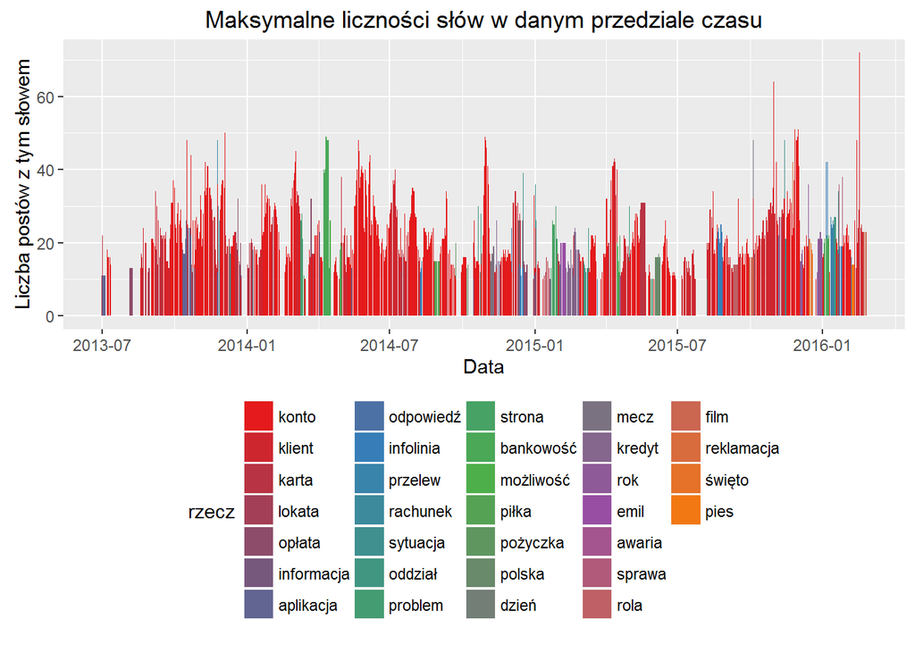

Następnie odfiltrowaliśmy dane dla tych słów, które mają udział w najczęściej pojawiających się słowach nie większy niż 2%. Podejrzewamy, że dla tych słów podczas tych wystąpień w postach kiedy pojawiały się częściej niż inne zachodziły ciekawe i niecodzienne wydarzenia. Oto wykres tylko dla wyselekcjonowanych słów.

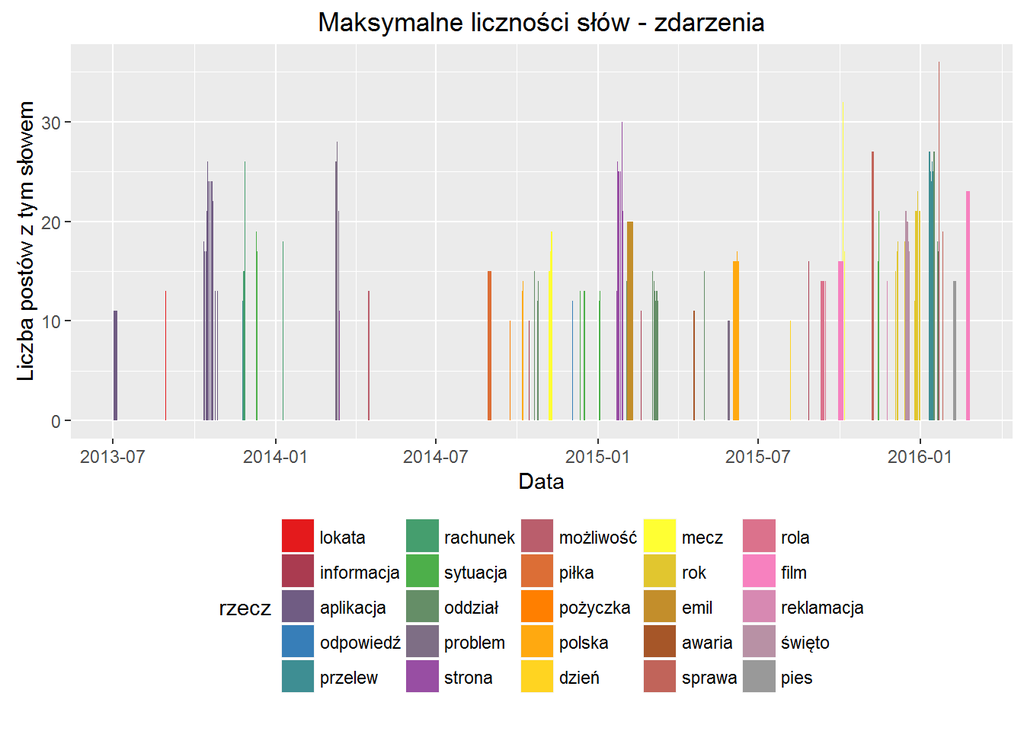

Dla trzech wybranych słów: **film**, **aplikacja** i **emil**, zostały przedstawione posty z datami wystąpienia oraz w przewidywanym podziale na zdarzenia.

## film

### Zdarzenie 1

#### Data: 2015-10-05

- konkurs filmowy! Obraz i dźwięk. Były i są kluczowe w historii kina. Bywa tak, że piosenka, czy melodia, jest największym atutem filmu, a czasem nawet go przyćmiewa. Jakie są Wasze ulubione filmowe utwory muzyczne? Jakie emocje w Was budzą? Dlaczego są wyjątkowe? Napiszcie w komentarzu, a 10 najciekawszych odpowiedzi nagrodzimy podwójnymi wejściówkami do kin :) Regulamin -> https://www.aliorbank.pl/dam/jcr:3379507b-fce8-48e7-a355-0cc4f1643396/2015-10-05-regulamin-konkursu-bilety-do-kina-5-6-10-2015.pdf
- https://www.youtube.com/watch?v=VEJ8lpCQbyw Muzyka zespołu Queen z filmu Nieśmiertelny.Moim zdanie to muzyka największy atut tego filmu.
- Zdecydowanie “Hans Zimmer & Lisa Gerrard - Now We Are Free” ta piosenka w połączeniu z moim ulubionym filmem oraz wręcz legendarną chwilą - wyciska ze mnie łzy, jest po prostu piękna, wracam do niej bardzo często gdyż Gladiator to produkcja wyjątkowa! https://www.youtube.com/watch?v=-yOZEiHLuVU
- Niesamowita muzyka napisana przez Ludovico Einaudi - Una Mattina - do filmu “Nietykalni” nadaje niepowtarzalnego charakteru i staje się nośnikiem emocji oraz wartości, które autor chciał przekazać w tym genialnym arcydziele kinematografii. https://www.youtube.com/watch?v=EoaPhxNubL0
- Według mnie Quentin Tarantino to mistrz dobierania muzyki i tworzenia klimatu filmu! Jego kunszt można usłyszeć w filmie Bękarty Wojny. Najbardziej zapadła mi melodia “The Surrender (La Resa) - Ennio Morricone” podczas której Sierżant Donny Donowitz powolnym krokiem zmierzał do nazisty aby ukarać go bejsbolem :D Melodia ta wyraża więcej niż milion słów! https://www.youtube.com/watch?v=Z8qkHwszVUc
- Dla mnie muzyka świetnie uzupełniała film “Never Back Down” i magiczny kawałek Kanye West - Stronger. Oglądając film i słuchając tego kawałka ma się gęsią skórkę i przechodzą dreszcze.. Muza ta nieźle motywuje, podnosi poziom adrenaliny, że ma się ochotę wstać i nawalać w worek! https://www.youtube.com/watch?v=7uO8-8hx0Dg
- Muzyka z filmu “przekręt”…absolutnie genialna, pobudzajaca, pozwalająca poczuć film wszystkimi zmysłami :-)
- Jestem kinomaniaczką, to fakt. Drugi fakt jest taki, że jeśli chodzi o filmy, jestem również wzrokowcem i stawiam po pierwsze na zdjęcia i scenariusz, an grę aktorską, dopiero później na muzykę - musi być naprawdę niezwykła, żeby stała się dla mnie głównym bohaterem…A tak dzieje się zawsze, kiedy na ekranie słyszę Clinta Mansella, najczęściej współpracującego z jednym z moich ulubionych reżyserów, Darrenem Aronofsky’m. Requiem for a Dream zna chyba każdy, tak samo jak chyba każdy zna ścieżkę dźwiękową z tego filmu - to właśnie efekt współpracy tych dwóch Panów…Dla mnie jednak o wiele bardziej magiczna i chwytająca za wyobraźnię jest muzyka z filmu The Fountain, wspaniale oddająca ten z pogranicz jawy i snu klimat. Za każdym razem, kiedy jej słucham, czuję się jakby oderwana od rzeczywistości - to muzyka, która opowiada tyle samo, co obrazy, a może nawet więcej - bo potrafi zagrać nam w duszy nuty, o których nie mieliśmy wcześniej pojęcia… https://www.youtube.com/watch?v=2jKLTzbBBHA
- Muzyka z filmu NOCE I DNIE piękna muzyka romantyczna do słuchania we dwoje i do tańczenia
- Ponadczasowa piosenka, tak jak ponadczasowy film :) Zawsze z rozbawieniem wspominam przy tej piosence szloch wszystkich dzieci na sali kinowej, gdy umiera Mufasa. :D Król Lew <3 Elton John - Can You Feel The Love Tonight https://www.youtube.com/watch?v=dQ2YNKbGqFc
- Ulubiony kawałek? “Season of Love” z filmu “R.E.N.T.” :) Przepiękny musical i przepiękne piosenki… Utwór jak sam tytuł mówi jest o miłości.. by życie i upływający czas nie liczyć kalendarzowo.. nie odliczać minut tak zwyczajnie, a przeliczać je na wspólne chwile, drobne gesty, cieszyć się życiem, dniem, zachodami słońca, kubkiem kawy.. doceniać :) Piosenka ta nauczyła mnie mierzyć życie odpowiednią miarą (sercem) https://www.youtube.com/watch?v=hj7LRuusFqo
- Piosenka przyćmiewająca fil to jak dla mnie Coolio - Gangsta’s Paradise z filmu “Młodzi Gniewni”, . Świetny kawałek, który towarzyszył mi w fazie buntu ale również przy tym kawałku były również bardzo fantastyczne chwile, które powracają przy słuchaniu tej piosenki. https://www.youtube.com/watch?v=NS6-IpqPp9g
- ścieżka dźwiękowa z filmu Strażnicy Galaktyki :) to ubiegłoroczna produkcja Marvela :) uwielbiam wszystkie utwory…i jeszcze ten walkman…z którego muzyki w filmie słucha Starlord… a z wcześniejszych produkcji to muzyka z serialu Ally Mc Beal i moja najukochańsza piosenka Barrego :) :) :) https://youtu.be/Fcd3XuQwDQQ
- Jak dla mnie jest tylko jeden film i jedna piosenka, a mianowicie film Dirty Dancing ze słynnym kawałkiemTime of my Life. Ten niepowtarzalny i kultowy film mogę oglądać zawsze i wszędzie i zawsze mnie rozczula i sprawia że czuję się młodsza :) https://www.youtube.com/watch?v=WpmILPAcRQo
- Kiler to film ,do którego powracam, bo mimo, że lekko się go ogląda to też ma w sobie morały. Do tego ta kultowa piosenka, którą chyba każdy z nas kiedyś nucił https://www.youtube.com/watch?v=-OfXA_1boWQ
- Takich piosenek czy ścieżek filmowych mogę wymienić wiele.Są takie piosenki które słysząc w radio od razu widzę sceny z filmu i budzą we mnie różne emocje od wzruszenia po śmiech.Na pewno jednymi z moich ulubionych piosenek są nieśmiertelna Withney ze swoim " I will always love You" z “Bodyguarda” czy “Shape of my heart” z “Leona Zawodowca” a najnowszych produkcji ścieżka dźwiękowa z “50 Twarzy Greya”

### Zdarzenie 2

#### Data: 2016-02-25

- Zbliża się najbardziej wyczekiwana przez wielbicieli kina noc. Zachęcamy Was do wytypowania zwycięzców tegorocznych Oscarów w 5 kategoriach: najlepszy film, najlepszy aktor pierwszoplanowy, najlepsza aktorka pierwszoplanowa, najlepszy reżyser oraz najlepsza piosenka. Wśród osób, które poprawnie wskażą tegorocznych zdobywców Nagród Akademii Filmowej nagrodzimy 10 osób, które zrobią to najszybciej. Konkurs trwa do soboty (27.02), do końca dnia. Regulamin: https://www.aliorbank.pl/dam/jcr:a7241596-83e9-46ad-8b90-edcfcabf4a30/regulamin-konkursu-oscary-2016-25-02-2016.pdf konkurs nagrody
- Najlepszy film - “Zjawa” Najlepszy reżyser - Alejandro G. Inarritu Najlepszy aktor pierwszoplanowy - Leonardo DiCaprio Najlepsza aktorka pierwszoplanowa - Brie Larson Najlepsza piosenka - “Writing’s on the Wall”, wyk. Sam Smith
- Najlepszy film - “Zjawa” Najlepszy reżyser - Alejandro G. Inarritu Najlepszy aktor pierwszoplanowy - Leonardo DiCaprio Najlepsza aktorka pierwszoplanowa - Brie Larson Najlepsza piosenka - “Writing’s on the Wall”, wyk. Sam Smith
- Najlepszy film: Zjawa Najlepszy aktor pierwszoplanowy: Leonardo di Caprio Najlepsza aktorka pierwszoplanowa: Brie Larson Najlepszy reżyser: Alejandro González Inárritu Najlepsza piosenka: “Writing’s on the Wall”, wyk. Sam Smith (II)
- Najlepszy film: Zjawa Najlepszy aktor pierwszoplanowy: Leonardo di Caprio Najlepsza aktorka pierwszoplanowa: Brie Larson Najlepszy reżyser: Alejandro González Inárritu Najlepsza piosenka: “Writing’s on the Wall”, wyk. Sam Smith
- Najlepszy film: Zjawa Najlepszy aktor pierwszoplanowy: Matt Damon, “Marsjanin” Najlepsza aktorka pierwszoplanowa: Cate Blanchett, “Carol” Najlepszy reżyser: Alejandro G. Inarritu, “Zjawa” Najlepsza piosenka:“Writing’s On The Wall” z filmu “Spectre”
- Najlepszy film: Zjawa Najlepszy aktor pierwszoplanowy: Leonardo di Caprio Najlepsza aktorka pierwszoplanowa: Cate Blanchet Najlepsza piosenka: Writing’s on the Wall Najlepszy reżyser: Alejandro González Inárritu
- Najlepszy film - “Zjawa” Najlepszy reżyser - Alejandro G. Inarritu Najlepszy aktor pierwszoplanowy - Leonardo DiCaprio Najlepsza aktorka pierwszoplanowa - Brie Larson Najlepsza piosenka - “Writing’s on the Wall”, wyk. Sam Smith
- Najlepszy film: Zjawa Najlepszy aktor pierwszoplanowy: Leonardo di Caprio Najlepsza aktorka pierwszoplanowa: Jennifer Lawrence Najlepsza piosenka: Writing’s on the Wall Najlepszy reżyser: Alejandro González Inárritu
- Najlepszy film: “Zjawa” Najlepszy aktor pierwszoplanowy:-Leonardo DiCaprio “Zjawa” Najlepsza aktorka pierwszoplanowa: Cate Blanchett, “Carol” Najlepszy reżyser: Alejandro G. Inarritu, “Zjawa” Najlepsza piosenka:“Writing’s On The Wall” z filmu “Spectre”
- Najlepszy film: Zjawa Najlepszy aktor pierwszoplanowy: Leonardo di Caprio Najlepsza aktorka pierwszoplanowa: Cate Blanchet Najlepsza piosenka: Writing’s on the Wall Najlepszy reżyser: Alejandro González Inárritu
- Najlepszy film: Zjawa Najlepszy aktor pierwszoplanowy: Leonardo di Caprio Najlepsza aktorka pierwszoplanowa: Cate Blanchet Najlepsza piosenka: Writing’s on the Wall Najlepszy reżyser: Alejandro González Inárritu
- Najlepszy film: Zjawa Najlepszy aktor pierwszoplanowy: Leonardo di Caprio Najlepsza aktorka pierwszoplanowa: Brie Larson Najlepszy reżyser: Alejandro González Inárritu Najlepsza piosenka: “Writing’s on the Wall”, wyk. Sam Smith
- Najlepszy film - “Zjawa” Najlepszy reżyser - Alejandro G. Inarritu Najlepszy aktor pierwszoplanowy - Leonardo DiCaprio Najlepsza aktorka pierwszoplanowa - Brie Larson Najlepsza piosenka - “Writing’s on the Wall”, wyk. Sam Smith
- Najlepszy film: Zjawa Najlepszy aktor pierwszoplanowy: Leonardo di Caprio Najlepsza aktorka pierwszoplanowa: Brie Larson Najlepszy reżyser: Alejandro González Inárritu Najlepsza piosenka: “Writing’s on the Wall”, wyk. Sam Smith (II)
- Najlepszy film: Zjawa Najlepszy aktor pierwszoplanowy: Leonardo di Caprio Najlepsza aktorka pierwszoplanowa: Brie Larson Najlepszy reżyser: Alejandro González Inárritu Najlepsza piosenka: “Writing’s on the Wall”, wyk. Sam Smith (II)
- Najlepszy film - “Zjawa” Najlepszy reżyser - Alejandro G. Inarritu Najlepszy aktor pierwszoplanowy - Leonardo DiCaprio Najlepsza aktorka pierwszoplanowa - Brie Larson Najlepsza piosenka - “Writing’s on the Wall”, wyk. Sam Smith
- Najlepszy film: Spotlight Najlepszy aktor pierwszoplanowy: Leonardo di Caprio Najlepsza aktorka pierwszoplanowa:Brie Larson Najlepszy reżyser: Alejandro González Inárritu Najlepsza piosenka “Spectre”,„Writing’s on the Wall”, Sam Smith
- Najlepszy film - “Zjawa” Najlepszy reżyser - Alejandro G. Inarritu Najlepszy aktor pierwszoplanowy - Leonardo DiCaprio Najlepsza aktorka pierwszoplanowa - Brie Larson Najlepsza piosenka “Pole walki”, piosenka „Til It Happens to You”, Lady Gaga
- Najlepszy film: Zjawa Najlepszy aktor pierwszoplanowy: Leonardo di Caprio Najlepsza aktorka pierwszoplanowa: Brie Larson Najlepsza piosenka: Writing’s on the Wall Najlepszy reżyser: Alejandro González Inárritu
- Najlepszy film: “Pokój” Najlepszy aktor pierwszoplanowy: Matt Damon Najlepsza aktorka pierwszoplanowa: Brie Larson Najlepsza reżyseria: Lenny Abrahamson Najlepsza piosenka: “Writing’s on the Wall”, wyk. Sam Smith

#### Data: 2016-02-28

- O tym, kto zostanie okrzyknięty najlepszym w świecie filmu przekonamy się już dziś! Przed nami 88. ceremonia wręczenia Oscarów! Kto z Was zdecyduje się na bezsenną noc i będzie śledził relację z oscarowej gali?
- wg mnie takie konkursy to kompletny bezsens, większość tych oskarowych filmów jest po prostu kiepska

## aplikacja

### Zdarzenie 1

#### Data: 2013-07-08

- NOWOŚĆ W ALIOR BANKU! Miło nam poinformować, że dzisiaj udostępniliśmy nową wersję aplikacji mobilnej na system iOS dostosowaną do telefonów iPhone 5. Zachęcamy do pobierania nowej wersji aplikacji i jak zwykle liczymy na pozytywne komentarze! ;) Jeśli aplikacja automatycznie nie zaktualizowała Wam się do najnowszej wersji, to po wyszukaniu aplikacji w AppStore, należy wybrać link “Update” lub skontaktować się z naszą infolinią.
- Aplikacja wysypuje się na iOS 7 Beta.
- czy na ipada też jest aplikacja ?
- A kiedy zajmiecie się aplikacją dla kont firmowych. Czy w ogóle jest to dla was ważny segment rynku? Dajcie znać bo nie wiem czy czekać czy konto przenosić?
- Marcin Soyka: Za pośrednictwem aplikacji mobilnej nie ma możliwości obsługi konta firmowego. Prosimy w takiej sytuacji o korzystanie z serwisu transakcyjnego w wersji lajt, który jest dostępny pod adresem: https://m.aliorbank.pl/mobile/do/Logi [Magda]
- Mateusz Łuniewski: Klienci Alior Banku mogą korzystać z aplikacji na tablety. Więcej informacji na ten temat znajdziesz na stronie: http://www.aliorbank.pl/pl/bankowosc_elektroniczna/mobile/aplikacjenatabletach [Magda]
- Marcin Fąfara: Obecnie nie planujemy przygotowania dedykowanej aplikacji na system BlackBerry - zachęcamy do korzystania z mobilnej wersji naszego serwisu. [Magda]
- Mateusz Ponikowski: Aplikacja nie działa w wersji iOS 7 Beta, prawdopodobnie dlatego, że nie jest to jeszcze oficjalna wersja systemu. Nie zamierzamy przestać rozwijać naszych aplikacji. Zakładamy jednak, że Apple przygotuje system zachowując kompatybilność wsteczną, tak aby producenci nie musieli dokonywać zmian w swoich aplikacjach. Jeżeli jednak konieczne będzie dostosowanie aplikacji do iOS 7, na pewno to uczynimy. [Magda]
- To trochę kpina, bo iPhone 5 jest już na rynku od prawie roku. Trochę dług Wam zeszło, aby dostosować tą aplikację.
- Jakub Stanisław Wolak: Naszym celem jest, aby dostosowanie naszych aplikacji mobilnych do nowo pojawiających się urządzeń, trwało jak najkrócej. Przykro nam, że w tym zakresie nie spełniliśmy Twoich oczekiwań. [Magda]
- Dalej czekam na aplikację na tablety z Androidem. Co nie powinno być problemem, jak jest na telefon (a konkurencja potrafi).

### Zdarzenie 2

#### Data: 2013-10-12

- Kiedy w końcu poprawią Państwo aplikację na iPhone??? Od aktualizacji iOS do wersji 7 apka jest prawie bezużyteczna! Nie da sie zatwierdzać przelewów lub zmienić sposobu logowania, ponieważ przycisk “Wyślij” (przelewy) jest zasłaniany dolną belką z przyciskiem “Wyloguj”. Patrząc na komentarze AppStore problem dotyczy iPhone 4, 4S, 5 i zapewne 5s.

#### Data: 2013-10-14

- Kiedy można spodziewać się aplikacji działającej na Nexus 4?
- @Grzegorz: Obecnie pracujemy nad dostosowaniem naszej aplikacji do iOS7. O udostępnieniu nowej wersji aplikacji na pewno poinformujemy Was na Facebooku. Prosimy o jeszcze odrobinę cierpliwości. [Magda]
- Nie chcę się czepiać, ale od premiery iOS7 minał już niemal miesiąc (bez 4 dni). To sporo czasu na wykonanie małej poprawki. Wszystkie, nawet mało ważne aplikacje (aplikację bankową umieściłbymw kategorii - ważniejsze) jakie posiadam już od dłuższego czasu mają poprawki do kompatybilności z iOS7. Poza tym premiera próbnej wersji systemu, do której już można było zacząć dostosowywanie zmian miała miejsce 10 czerwca 2013 - czyli ponad 4 miesiace temu… W tyle czasu można praktycznie zrobić aplikację od zera a tutaj mamy do czynienia z sytuacją, gdzie wymagana jest tylko drobna poprawka… Mam o to duży żal do Państwa, ponieważ banki mają (z reguły) powszechną opinię poważnych instytucji a do tego Alior sprzed lat BYŁ bardzo innowacyjnym bankiem, także pod względem bankowości elektronicznej (w tym mobilnej). Mam wrażenie, że innowacyjność i dbanie i produkty bankowości elektronicznej idzie teraz w Alior Sync a Alior od którego wszystko się zaczęło jest gdzieś na dalszym planie… Szkoda Rozumiem, że mają Państwo zewnętrznego dostawcę aplikacji, ale przecież on najlepiej będzie wiedział ile to wymaga czasu (zakładam, że prace nad poprawką są wyceniane a dostawca otrzymuje wynagrodzenie za czas potrzebny na prace. Tak przynajmniej działa większośc sektora IT, w którym pracuję). Proszę o bardziej konkretne podanie terminu niż sformułowanie typu “odrobina cierpliwości” lub “trwają pracę”. Kiedy można spodziewać się poprawki? Za kilka dni, tydizeń, dwa a może jeszcze więcej? Jestem pewny że da się ustalić przybliżoną datę.
- No i nie można było napisać: “Poprawiona aplikacja czeka na zatwierdzenie przez Apple i zostanie opublikowana w ciągu 1-5 dni”? :) Poprawka właśnie pojawiła się w AppStore i funkcjonalnośc już działa poprawnie.

#### Data: 2013-10-15

- Dobra wiadomość dla użytkowników iPhone’ów! W App Store jest już dostępna nowa wersja naszej aplikacji mobilnej dostosowana do iOS7. Zachęcamy do pobierania aplikacji i liczymy na pozytywne komentarze! Więcej informacji o aplikacji mobilnej Alior Banku znajdziecie na stronie: http://www.aliorbank.pl/pl/bankowosc_elektroniczna/mobile/smartfone
- Czy apliakcja w końcu ma możliwość przełączenia kontekstu - aby np. mieć podgląd w konto firmowe ? Nie ukrywam, że jest to mega problematyczne kiedy trzeba wyłączać aplikację aby wejść w “ubogą wersję mobilną bankowości” elektronicznej aby przejrzeć konto firmowe? Czy można spodziewać się dodania tej opcji do aplikacji mobilnej w podobny sposób jak to ma miejsce w przeglądarce na smartfone ?
- @Adam: Za pośrednictwem aplikacji mobilnej można obsługiwać obecnie wyłącznie konta indywidualne. Klientów posiadających rachunki firmowe zachęcamy do korzystania z naszego serwisu w wersji light. [Magda]
- No tak tylko jest to mało intuicyjne. Czy planujecie jakoś “dodać” możliwość zmiany kontekstu wyświetlania bankowości w samej aplikacji.
- @Piotr: Obecnie pracujemy nad przystosowaniem aplikacji na Nexus 4. [Magda]
- No, o co chodzi. Aplikacja banku i nie jest dostosowana do najnowszych wersji systemu?
- A co z aplikacją dla Androida 4.3? Programiści śpią?
- Adam Borodo: Cały czas pracujemy nad nowymi produktami i usługami. Niewykluczone, że w przygotujemy również aplikację mobilną dla klientów firmowych. [Magda]
- Patryk Solarz: Konta walutowe klientów indywidualnych można obsługiwać za pośrednictwem aplikacji mobilnej. [Magda]
- @Piotr: Obecnie pracujemy nad przystosowaniem aplikacji na Nexus 4. [Magda] - o takie odpowiedzi znacznie bardziej lubię :)
- Mam iPhona4. Przed aktualizacją systemu do iOS7 wszystko było ok. Od momentu aktualizacji cały czas mam komunikat o błędzie logowania. Robiłem już wszystko: przeinstalowałem oprogramowanie telefonu, wgrałem aktualizację waszej aplikacji i d… :( Co mam zrobić żebym w końcu mógł normalnie używać waszej aplikacji?

#### Data: 2013-10-16

- Andrzej Libiszewski: Obecnie pracujemy nad przystosowanie aplikacji do Androida 4.3 [Magda]
- Alior Bank Brawo, jesteście tak wielcy, że po prostu nie ogarniam waszej wielkości. Wiecie może przypadkiem, że w ciągu dwóch tygodni będzie już Android 4.4? Czyli aplikacja dla mnie nadal nie będzie działała (bo mój telefon dostanie aktualizację i to raczej od razu) i będę musiał czekać pewnie kolejne 3 miesiące, aż ktoś łaskawie zaktualizuje ją do pracy z wersją 4.4. Jak pisałem, jesteście NAPRAWDĘ wielcy.

#### Data: 2013-10-21

- Chętnie przetestował bym mobilne płatności w biedronce, ale na razie nawet nie wiem czy na windows phone dostępna jest aplikacja, a strona leży …
- Po spadku notowań na giełdzie następna klapa banku. Dzisiaj ruszyła akcja w sieci “biedronka” gdzie można płacić telefonem za pomocą aplikacji “ikasa”. No i błąd można płacić w dwóch bankach biorących udział bo reklamujący się tam Aliorbank nie ma tej aplikacji jeszcze sprawnej. Moje gratulacje. Jesteście zawsze na końcu :)
- @Tomasz: Aplikacja na pewno będzie dzisiaj dostępna. Prosimy o jeszcze odrobinę cierpliwości. [Magda]
- @Marcin: Obecnie czekam na udostępnienie aplikacji w Google Play. Prosimy o jeszcze odrobinę cierpliwości. [Magda]
- Wpisz ikasa Alior Bank i ci się wyświetli oficjalna aplikacja. Ja już się zarejestrowałem. Trzeba sprawdzić jak to działa w praktyce.
- Bartosz Grzegowski: Obecnie z aplikacji iKasa mogą korzystać wyłącznie Klienci Alior Banku. [Magda]
- KRAJOWY MOBILNY STANDARD PŁATNICZY Wprowadzony przez PKO BP system IKO, (IKO to system umożliwiający dokonywanie płatności telefonem, bez użycia karty płatniczej czy też gotówki) – sukcesywnie rozszerza się. Po podpisaniu umowy (z Bankiem Millennium, ING Bankiem Śląskim, BRE Bankiem, Bankiem Zachodnim WBK oraz Alior Bankiem) – zapoczątkowany przez PKO BP system IKO, powoli staje się krajowym systemem płatności mobilnych… Dzięki temu, kilkanaście milionów klientów uzyskało dostęp do płatności mobilnych, za pomocą telefonu komórkowego z funkcją internetu… Dzisiaj, każdy może korzystać z płatności mobilnych (po wcześniejszym ściągnięciu i zainstalowaniu IKO na telefonie), ponieważ uruchomiona została tzw. Portmonetka. Czyli narzędzie które zasila się środkami finansowymi (np. poprzez przelew z dowolnego rachunku bankowego, jeśli nie ma się konta w PKO BP). A na jakich telefonach działa IKO? Na telefonach z systemami operacyjnymi: Windows, Symbian, BlackBerry, Android, iOS. A także na telefonach umożliwiających instalację aplikacji Java. A jak wygląda sam proces płatności w sklepie? Bardzo prosto. Po zalogowaniu się do aplikacji IKO kodem PIN (wybranym podczas aktywacji), bierze się do ręki terminal płatniczy podany przez sprzedawcę i wpisuje sześciocyfrowy kod IKO, widoczny na ekranie telefonu. I płatność zostaje dokonana! Podobnie można dokonać płatności w sklepie internetowym (albo wypłacić pieniądze w bankomacie). Jedyna różnica polega na tym, że sześciocyfrowy kod IKO, wpisuje się na ekranie komputera lub na ekranie bankomatu. ———————————————————————————— Powyższy tekst pochodzi z witryny Mikserek. Witryna Mikserek, oferuje pomoc merytoryczną w zakresie kredytów, pożyczek, chwilówek oraz rozmaitych sposobów inwestowania pieniędzy. Zapraszamy do odwiedzenia witryny >> http://www.mikserek.weebly.com/
- KRAJOWY MOBILNY STANDARD PŁATNICZY Wprowadzony przez PKO BP system IKO, (IKO to system umożliwiający dokonywanie płatności telefonem, bez użycia karty płatniczej czy też gotówki) – sukcesywnie rozszerza się. Po podpisaniu umowy (z Bankiem Millennium, ING Bankiem Śląskim, BRE Bankiem, Bankiem Zachodnim WBK oraz Alior Bankiem) – zapoczątkowany przez PKO BP system IKO, powoli staje się krajowym systemem płatności mobilnych… Dzięki temu, kilkanaście milionów klientów uzyskało dostęp do płatności mobilnych, za pomocą telefonu komórkowego z funkcją internetu… Dzisiaj, każdy może korzystać z płatności mobilnych (po wcześniejszym ściągnięciu i zainstalowaniu IKO na telefonie), ponieważ uruchomiona została tzw. Portmonetka. Czyli narzędzie które zasila się środkami finansowymi (np. poprzez przelew z dowolnego rachunku bankowego, jeśli nie ma się konta w PKO BP). A na jakich telefonach działa IKO? Na telefonach z systemami operacyjnymi: Windows, Symbian, BlackBerry, Android, iOS. A także na telefonach umożliwiających instalację aplikacji Java. A jak wygląda sam proces płatności w sklepie? Bardzo prosto. Po zalogowaniu się do aplikacji IKO kodem PIN (wybranym podczas aktywacji), bierze się do ręki terminal płatniczy podany przez sprzedawcę i wpisuje sześciocyfrowy kod IKO, widoczny na ekranie telefonu. I płatność zostaje dokonana! Podobnie można dokonać płatności w sklepie internetowym (albo wypłacić pieniądze w bankomacie). Jedyna różnica polega na tym, że sześciocyfrowy kod IKO, wpisuje się na ekranie komputera lub na ekranie bankomatu. ———————————————————————————— Powyższy tekst pochodzi z witryny Mikserek. Witryna Mikserek, oferuje pomoc merytoryczną w zakresie kredytów, pożyczek, chwilówek oraz rozmaitych sposobów inwestowania pieniędzy. Zapraszamy do odwiedzenia witryny >> http://www.mikserek.weebly.com/

#### Data: 2013-10-22

- Marcin Zieliński: Tristan Tomczak ma rację. Aplikacja iKASA jest już dostępna w Google Play. [Magda]
- Beata De S-kropka: Z aplikacji iKASA mogą korzystać również Klienci, którzy posiadają Konto Osobiste z tym że nie otrzymają oni zwrotu 5% wartości dokonanych zakupów. [Magda]
- Beata De S-kropka: Aby skorzystać z płatności mobilnych iKASA w Alior Banku, należy pobrać aplikację i zarejestrować się na stronie http://www.biedronka.aliorbank.pl. Po zakończeniu rejestracji, na wprowadzony w formularzu rejestracyjnym numer telefonu, otrzymasz kod startowy do aplikacji iKASA. Kod startowy jest jednorazowy, a jego okres ważności wynosi 30 minut. [Magda]
- Zakupy w Biedronce 5% tańsze? Teraz to możliwe! Wystarczy założyć Konto Rozsądne w Alior Banku i płacić za zakupy telefonem korzystając z dedykowanej aplikacji mobilnej iKASA. Korzystne, prawda? :) Szczegółowe informacje na stronie: http://www.biedronka.aliorbank.pl/ Instrukcja korzystania z aplikacji iKASA dostępna jest tutaj: http://www.aliorbank.pl/resources/res/repozytorium_dokumentow/klienci_indywidualni/ikasa_instrukcja_uzytkownika.pdf
- Kiedy pojawi sie aplikacja do płacenia wszędzie, nie tylko w biedronce?
- A czy takowa aplikacja jest również dostępna dla klientów Alior Sync?
- Czy tym można płacić tylko w biedronce? Kiedy pojawi się aplikacja do płacenia wszędzie, gdzie jest czytnik nfc- zblizeniowy?
- Jeicam Sadjak Sadjak: Aplikacja na iOS jest już dostępna. [Magda]
- Wojciech Lieder; Artur Kałżyński: Obecnie z aplikacji iKASA mogą korzystać wyłącznie Klienci Alior Banku. [Magda]
- a co z aplikacją na Windows Phone 7 i 8?
- Dominik Gajewski: Tak, aplikacją iKASA obecnie można płacić wyłącznie w Biedronce. Nie znamy konkretnej daty udostępnienia płatności mobilnych w innych sklepach niż Biedronka. [Magda]
- IKASA - telefon Omnia I900, system operacyjny Windows Mobile 6.1, możliwość ściągnięcia aplikacja niby jest ale za każdym razem wywala mnie na stronę googla a tam aplikacja tylko na androida a nigdzie nie mogę znaleść na JAVĘ poza tym kod aktywacyjny dawno mi wygasł, i co teraz?
- @Beata: Z aplikacji iKASA mogą korzystać również Klienci, którzy posiadają Konto Osobiste z tym że nie otrzymają oni zwrotu 5% wartości dokonanych zakupów. [Magda]
- w którym miejscu po zalogowaniu się do konta mam włączyć używanie tej aplikacji?
- Beata De S-kropka: Instrukcja korzystania z aplikacja iKASA dostępna jest tutaj: http://www.aliorbank.pl/resources/res/repozytorium_dokumentow/klienci_indywidualni/ikasa_instrukcja_uzytkownika.pdf [Magda]
- A kiedy będzie dostępna aplikacja dla kont Sync?

#### Data: 2013-10-28

- Miło na poinformować, że w App Store (iOS) oraz w Google Play (Android) dostępna jest nowa aplikacja Alior Trader. Zachęcamy do jej pobierania i liczymy na pozytywne komentarze! ;) Więcej informacji o aplikacji na stronie: https://broker.aliorbank.pl/aktualnosci/aktualnosci-biura-maklerskiego/art,3162,alior-trader-mobile.html
- W jakim czasie możemy się spodziewać aplikacji giełdowej ?
- a aplikacja do obsługi konta nadal nie działa na androidzie 4.3
- A kiedy można się spodziewać połączenia konta firmowego z aplikacją mobilną?!
- Aplikacja na Windows phone też jest potrzebna!
- A wiecie, ze ta aplikacja ma dostęp do Waszych książek adresowych?

#### Data: 2013-10-29

- Bartosz Grzegowski: Obecnie pracujemy na dostosowaniem naszej aplikacji do systemu Android 4.3. Jak tylko udostępnimy nową wersję aplikacji na pewno Was o tym poinformujemy. [Magda]
- Zbyszko Św: Cały czas pracujemy nad rozszerzeniem naszej oferty produktów i usług. Niewykluczone, że przygotujemy również aplikację mobilną do obsługi kont firmowych. O wszystkich nowościach na bieżąco informujemy Was na Facebooku, więc zapraszamy do odwiedzania nas. [Magda]
- Waldek Jarczak: Obecnie nie planujemy udostępnienia aplikacji Alior Trader na WP8. [Magda]
- Michał Sadowski: Obecnie nie planujemy udostępnienia aplikacji na Windows Phone. [Magda]
- Patryk M. Kuliński: Obecnie nie znamy konkretnego terminu udostępnienia aplikacji do obsługi rachunków maklerskich. O wszystkich nowościach w naszej ofercie na bieżąco informujemy Was na Facebooku, więc zapraszamy do odwiedzania nas. [Magda]

#### Data: 2013-10-31

- Aliorze, kiedy pojawi się aplikacja mobilna na smartfony do obsługi konta firmowego? Aplikacja ikasa obsługuje tylko rachunki indywidualne a co z firmowymi?
- @Marcin: Nie znamy konkretnej daty udostępnienia aplikacji mobilnej do obsługi rachunków firmowych. O wszystkich nowościach w naszej ofercie na bieżąco informujemy Was na Facebooku, więc zapraszamy do odwiedzania nas. [Magda]

## emil

### Zdarzenie 1

#### Data: 2015-02-09

- Emil Jannings
- Emil Jannings
- Emil Jannings
- Emil Jannings
- Emil Jannings
- Emil Jannings
- Emil Jannings
- Emil Jannings
- Emil Jannings
- Emil Jannings
- Emil Jannings
- Emil Jannings
- Emil Jannings
- Emil Jannings
- Emil Jannings
- Emil Jannings
- Emil jannings
- Emil Jannings
- Emil Jannings
- Emil Jannings